# Using the gpc package

## Introduction

This package is presented as an accompaniment for the group project report for the COMPASS CDT, entitled *Pseudo-Marginal Inference for Gaussian Process Classification with Large Datasets*.

This package provides functionality to

- Choose an optimal subset of data that maximises the potential entropy score for a dataset, using the Information Vector Machine (IVM) algorithm (`ivm_subset_selection`)
- Fit a Gaussian process classification model (`gpc`)
- Plot, print and predict from this Gaussian process classification model ( `plot.gpc`, `print.gpc` and `predict.gpc`)

```r
library(gpc)
```

## Usage on the Spam Dataset

In the report, we show that this classification model provides a more accurate classification of the binary problem encountered in the e-mail spam dataset. The problem is as follows: Given a large dataset of emails, with their corresponding word and character frequencies for different cases, can we accurately predict whether a particular e-mail is spam or not spam?

### Loading the Data and Taking a Subset

We have provided access to the spam dataset as part of the package, which can be run with

```r
data(spam)
```

And format out the response and the predictor variables, as well as divide into testing and training datasets.

```r
cut = round(0.6*nrow(spam))
train_ind = sample(1:nrow(spam), cut)
test_ind = (1:nrow(spam))[-train_ind]
y = spam[train_ind, 1]
X = spam[train_ind, 2:ncol(spam)]
yp = spam[test_ind, 1]
Xp = spam[test_ind, 2:ncol(spam)]
```

The problematic part of fitting to this data immediately is its size:

```r
nrow(X)
```

```
#> [1] 2761
```

Since we are using MCMC methods with a pseudo marginal approach, fitting to this data for a sufficient amount of iterations will be incredibly time consuming. We instead choose a subset which maximises the entropy score for a given subset size. We use the `ivm_subset_selection` function implemented here, and choose a subset size $d=150$. We also need to specify the covariance function (or kernel) $k$, as well as the initial values of the hyperparameter vector $\boldsymbol{\theta}$, since these are used in the subset selection.

```r
kernel = function(x, y, theta) theta[1] * exp(-0.5 / theta[2]^2 * sum((x - y)^2))
init_theta = c(1, 1)
subset = ivm_subset_selection(X, kernel, init_theta, nsub = 150)
```

Now we can specify the model matrix $X$ and response vector $y$ that we will use for training the classification model.

```r
Xd = X[subset,]
yd = y[subset]
```

### Fitting the Model

The function `gpc` is a wrapper that calls the `Rcpp` functions that fit the classification model, including the pseudo marginal approximate likelihood and the Laplace approximation. These Rcpp functions are also written in parallel using `RcppParallel`, improving the speed of building the gram matrix $K$, and calculating the pseudo marginal approximation.

We fit the model as follows:

```r
gp_fit = gpc(y = yd,
             X = Xd,
             nsteps = 500,
             nburn = 250,
             nchains = 2,
             nimp = 100,
             init_theta = c(1, 1),
             kernel = "gaussian",
             print_every = Inf
)
```

```
#> Fitting a GP classification model.
#> Running with 2 chain, 500 steps.
#> Data length n = 150, dimension p = 57.
#> Number of hyperparameters:  2
#> _____________________________________
#> Chain 1 / 2 starting...
#> Warning in algo_1(y, X, nsteps, nburn, nimp, init_theta, init_marginal_lik, :
#> NAs introduced by coercion to integer range
#> Chain 1 Running: 1/500 iterations completed. || Acceptance ratio: 0
#>
#> Chain completed successfully.
#> Chain 2 / 2 starting...
#> Warning in algo_1(y, X, nsteps, nburn, nimp, init_theta, init_marginal_lik, :
#> NAs introduced by coercion to integer range
#> Chain 2 Running: 1/500 iterations completed. || Acceptance ratio: 0
#>
#> Chain completed successfully.
```

Now we can inspect the model using `plot.gpc`, an S3 method used for plotting `gpc` objects.

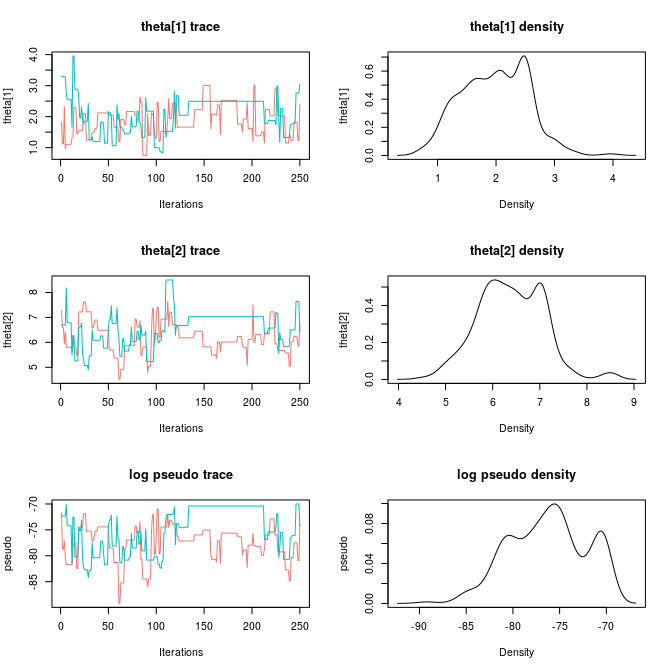

```r
plot(gp_fit)
```

By default, `plot.gpc` will plot the trace and density plots of the hyperparameters and the log pseudo marginal likelihood approximation. The argument `f=TRUE` will plot a series of the same plots for the latent variables $f$.

### Predicting from the Model

To obtain predictions from this fit, we can use `predict.gpc`, which averages across all values of hyperparameter vector `theta` across all samples and chains, to produce probabilities at each data point for the positive class.

```r
pred_train = predict(gp_fit, X)
```

Note that we fit the model to `Xd`, the subset model matrix, but predictions can be evaluated on the full training dataset. We do the same for the testing set.

```r
pred_test = predict(gp_fit, Xp)
```

From here, we can see the percentage of correct predictions in both cases (using a 0-1 loss, if the probabilities are greater than 0.5 then we predict the positive class, otherwise it is the negative class).

```r
output_pred_train = ifelse(pred_train > 0.5, 1, -1)
output_pred_test = ifelse(pred_test > 0.5, 1, -1)
```

The percentages are given by

```r
table(output_pred_train - y == 0)[2] / length(y)
```

```
#>      TRUE
#> 0.7921043
```

```r
table(output_pred_test - yp == 0)[2] / length(yp)
```

```
#>      TRUE
#> 0.8108696
```